# House Price Prediction Analysis

The real estate markets, like those in Sydney and Melbourne, present an interesting opportunity for data analysts to analyze and predict where property prices are moving towards. Prediction of property prices is becoming increasingly important and beneficial. Property prices are a good indicator of both the overall market condition and the economic health of a country. Considering the data provided, we are wrangling a large set of property sales records stored in an unknown format and with unknown data quality issues

Data Source link: https://www.kaggle.com/datasets/zafarali27/house-price-prediction-dataset/data

## 1. Introduction & Data Loading

The objective of this analysis is to build a regression model to predict the `Price` of a house based on the provided dataset. We will perform a rigorous analysis, including exploratory data analysis, feature engineering, and a comparison of multiple model types (linear, regularized, and non-linear) to find the model with the highest predictive power (R²).

### 1.1 Load Libraries

We begin by loading all necessary R packages for analysis, visualization, and modeling.

```r
library(dplyr)          # data manipulation
library(e1071)          # skewness
library(ggplot2)        # data visualizations
library(gridExtra)      # for arranging multiple ggplots into one figure
library(corrplot)       # correlation matrix visualization
library(RColorBrewer)   # color palettes for plots
library(caret)          # train/test splitting
library(glmnet)         # Ridge, LASSO, Elastic Net
library(randomForest)   # Random Forest
library(gbm)            # Gradient Boosting
library(car)            # Multicollinearity
```

### 1.2 Load Dataset

We upload the csv file to R and check the structure of the dataset and take a look to the first rows.

```r
house<- read.csv("House Price Prediction Dataset.csv")
head(house,3) #print first 3 rows
```

```
##   Id Area Bedrooms Bathrooms Floors YearBuilt Location Condition Garage  Price
## 1  1 1360        5         4      3      1970 Downtown Excellent     No 149919
## 2  2 4272        5         4      3      1958 Downtown Excellent     No 424998
## 3  3 3592        2         2      3      1938 Downtown      Good     No 266746
```

## 2. Descriptive Statistics & Data Overview:

### 2.1 Structure

The dataset has 2000 observations and 10 variables. `Location`, `Condition`, and `Garage` should be converted from `character` to `factor` for modeling.

```r
str(house)
```

```
## 'data.frame':    2000 obs. of  10 variables:
##  $ Id       : int  1 2 3 4 5 6 7 8 9 10 ...
##  $ Area     : int  1360 4272 3592 966 4926 3944 3671 3419 630 2185 ...
##  $ Bedrooms : int  5 5 2 4 1 1 1 2 2 3 ...
##  $ Bathrooms: int  4 4 2 2 4 2 1 4 2 3 ...
##  $ Floors   : int  3 3 3 2 2 1 2 1 1 1 ...
##  $ YearBuilt: int  1970 1958 1938 1902 1975 1906 1948 1925 1932 2000 ...
##  $ Location : chr  "Downtown" "Downtown" "Downtown" "Suburban" ...
##  $ Condition: chr  "Excellent" "Excellent" "Good" "Fair" ...
##  $ Garage   : chr  "No" "No" "No" "Yes" ...
##  $ Price    : int  149919 424998 266746 244020 636056 93262 448722 594893 652878 340375 ...
```

### 2.2 Data Cleaning

No missing values were detected in the dataset.

```r
colSums(is.na(house))
```

```
##        Id      Area  Bedrooms Bathrooms    Floors YearBuilt  Location Condition
##         0         0         0         0         0         0         0         0
##    Garage     Price
##         0         0
```

We convert ‘Bedrooms’, ‘Bathrooms’, ‘Floors’, ‘Location’, ‘Condition’, and ‘Garage’ variables into factors.

```r
# Function to convert columns to `factor`, removed `Id`
updated_df <- function(df) {
      cat_cols <- c('Bedrooms', 'Bathrooms', 'Floors', 'Location', 'Condition', 'Garage')
      # Convert categorical columns to factors
      df[cat_cols] <- lapply(df[cat_cols], as.factor)
      # Remove 'Id' column
      df <- df[, !names(df) %in% "Id"]
      return(df)
}
house_v2 <- updated_df(house)
```

The updated house_v2 dataset is well-structured, with numeric fields balanced and categorical variables properly encoded as factors with fairly balanced distributions. No obvious outliers like negative areas or Floors outside the expected range.

```r
summary(house_v2)
```

```
##       Area      Bedrooms Bathrooms Floors    YearBuilt        Location
##  Min.   : 501   1:418    1:461     1:661   Min.   :1900   Downtown:558
##  1st Qu.:1653   2:368    2:494     2:691   1st Qu.:1930   Rural   :474
##  Median :2833   3:406    3:524     3:648   Median :1961   Suburban:483
##  Mean   :2786   4:405    4:521             Mean   :1961   Urban   :485
##  3rd Qu.:3888   5:403                      3rd Qu.:1993
##  Max.   :4999                              Max.   :2023
##      Condition   Garage         Price
##  Excellent:511   No :1038   Min.   : 50005
##  Fair     :521   Yes: 962   1st Qu.:300098
##  Good     :461              Median :539254
##  Poor     :507              Mean   :537677
##                             3rd Qu.:780086
##                             Max.   :999656
```

### 2.3 Skewness

The skewness values for the numeric variables are all very close to 0, indicating that all variables are symmetric and do not require transformation.

```r
cols_num <- names(house_v2)[sapply(house_v2, is.numeric)]
skewed <- apply(house[cols_num],2, skewness) # 2 indicates column
print("skewed of Original Units")
```

```
## [1] "skewed of Original Units"
```

```r
skewed
```

```
##        Area   YearBuilt       Price
## -0.03849401 -0.00157477 -0.06425414
```

## 3. Exploration Data Analysis (EDA)

### 3.1 Distribution of numeric variables

The `Area` of the homes is spread out across the full range, without any heavy tail.

The `YearBuilt` values are fairly evenly distributed across the decades, giving the dataset a mix of older and newer homes.

The distribution of home `Price` is fairly uniform across the full range, with a slight linear trend.

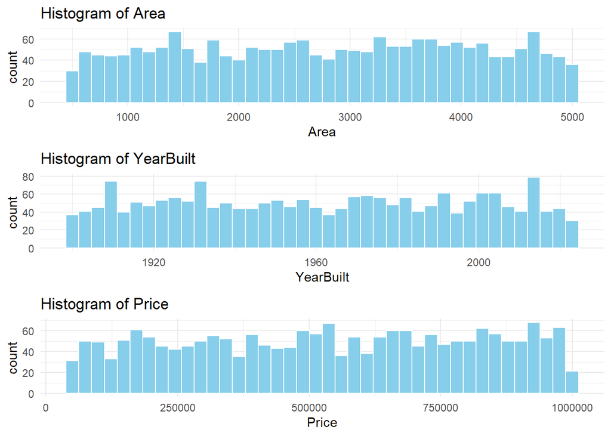

```r
plots <- list()

for (col in cols_num) {
  p <- ggplot(house_v2, aes(x = .data[[col]])) +
    geom_histogram(bins = 40, fill = "skyblue", color = "white") +
    labs(title = paste("Histogram of", col)) +
    theme_minimal()

  plots[[col]] <- p
}

grid.arrange(grobs = plots, ncol = 1) # Arrange all plots in a 1x3 grid
```

### 3.2 Distribution of categorical/factor variables

The pie charts provide an overview of the distribution of each categorical variable in the dataset. Overall, the categories appear relatively well balanced, with no extreme skews. `Bedrooms`, `Bathrooms`, and `Floors` show moderate variation across their levels, while `Garage` availability is split almost 50/50 between “Yes” and “No.

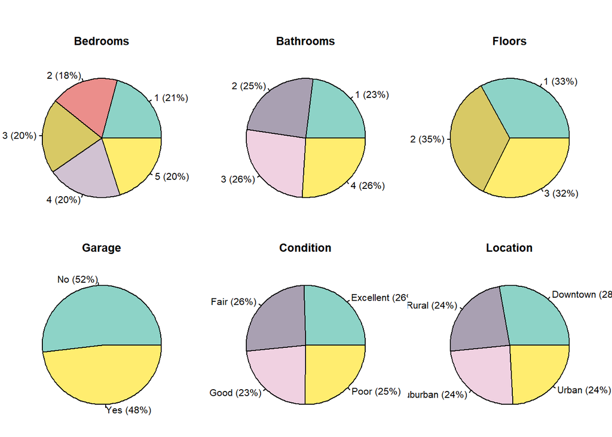

```r
cols_pie <- c("Bedrooms","Bathrooms","Floors","Garage","Condition","Location")

par(mfrow = c(2, 3),
    #smaller margins
    mar   = c(1, 1, 3, 1),
    oma   = c(0, 0, 2, 0))

for (col in cols_pie) {
  counts <- table(house_v2[[col]])
  pct    <- round(100 * counts / sum(counts))
  lbls   <- paste0(names(counts), " (", pct, "%)") #format labels
  pal <- colorRampPalette(brewer.pal(12, "Set3"))(length(counts)) #color palette
  pie(counts,
      labels = lbls,
      main   = col,
      col    = pal)
}
```

### 3.3 Box plot `Price` vs `categorical predictors`

The boxplots illustrate how housing prices vary across the different categories of each factor variable. Overall, price distributions appear broadly consistent across most groups, with similar medians and interquartile ranges, suggesting that these variables have not a visible influence on `Price` distribution

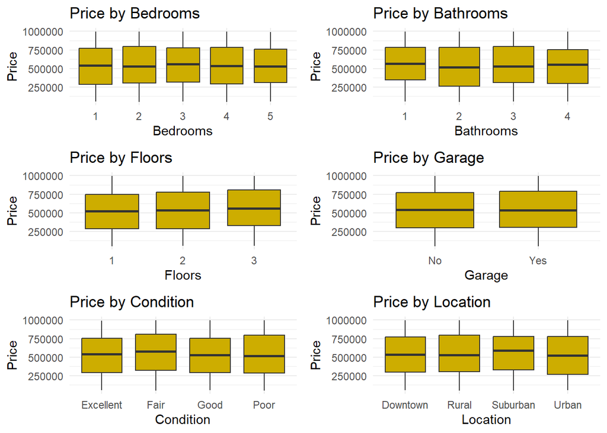

```r
cols_boxplot <- c("Bedrooms","Bathrooms","Floors","Garage","Condition","Location")

plot_list <- list()

for (col in cols_boxplot) {
  p <- ggplot(house_v2, aes_string(x = col, y = "Price")) +
    geom_boxplot(fill = "gold3") +
    labs(title = paste("Price by", col)) +
    theme_minimal()

  plot_list[[col]] <- p
}

grid.arrange(grobs = plot_list, ncol = 2) # Arrange all plots in a 2x3 grid
```

### 3.4 Scatter Plotting for `Price` vs `Area`

The scatter points are spread uniformly across the entire range of `Area` values. There is no visible trend, prices appear randomly distributed regardless of area. The red line (regression line) is horizontal, indicating that `Area` has no visual linear effect on `Price`.

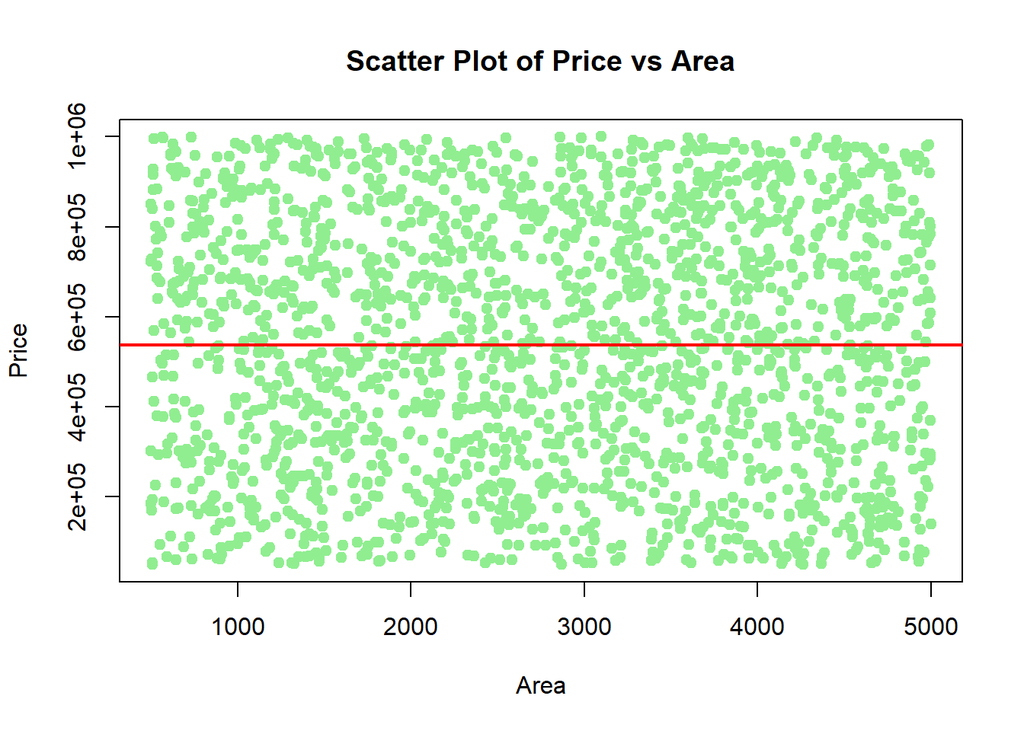

```r
plot(house_v2$Area, house_v2$Price,
     main = "Scatter Plot of Price vs Area",
     xlab = "Area",
     ylab = "Price",
     pch = 19,
     col = "lightgreen")
abline(lm(Price ~ Area, data = house), col = "red", lwd = 2)
```

### 3.5 Correlation Matrix

The predictors show weak linear correlation with `Price`, all pairwise correlations with Price are ~0 indicating no clear relationship. The only clear patterns appear along the dummy-variable groups (`Bedrooms, Bathrooms, Location, Condition, Floor`), which naturally correlate within their own categories.

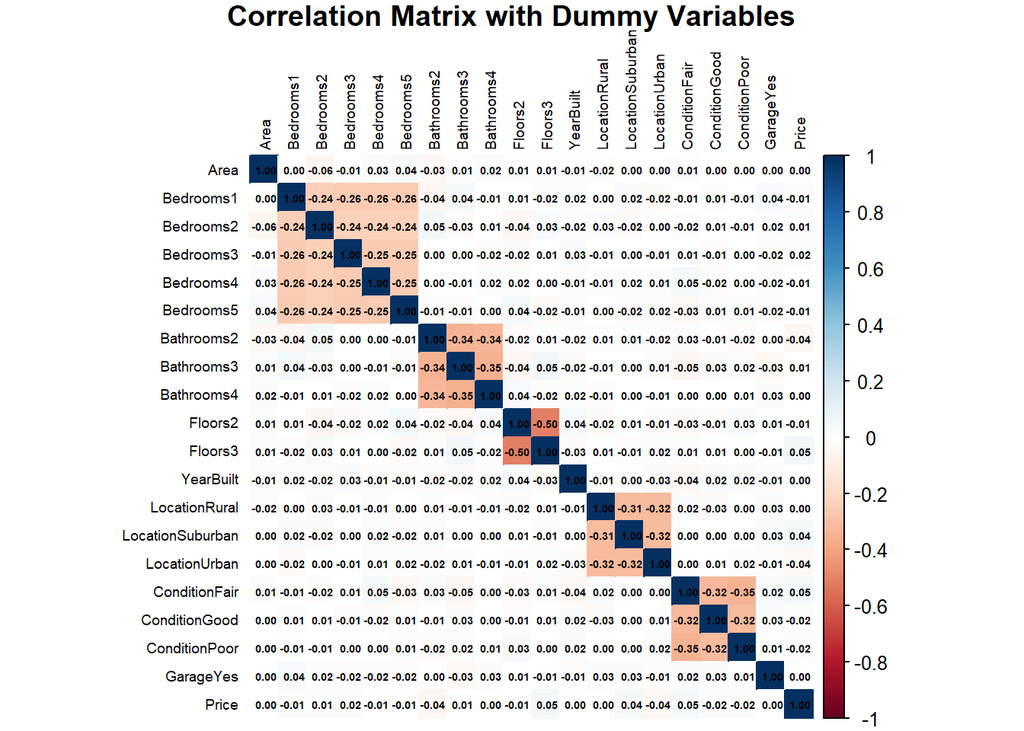

```r
# Convert factors to dummy variables
df_dummies <- model.matrix(~ . - 1, data = house_v2)
cor_matrix <- cor(df_dummies, use = "pairwise.complete.obs")

corrplot(cor_matrix,
         method = "color",
         addCoef.col = "black",
         number.cex = 0.45,
         tl.cex = 0.6,
         tl.col = "black",
         title = "Correlation Matrix with Dummy Variables",
         mar = c(0,0,1,0))
```

### 3.6 EDA Conclusion

Based on the EDA, `Price` shows weak relationships with the predictors, meaning the variables appear statistically independent of one another. Although this could point to a simplified or simulated dataset, we will continue with preprocessing and feature engineering to build a regression model and evaluate performance.

## 4. Feature Engineering and Data Split

### 4.1 Binning on `YearBuilt` variable

We group `YearBuilt` variable into 5 period bins to simplify the distribution. The groups are fairly balanced as expected.

```r
house_v2$YearBuiltBin <- cut(
                    house_v2$YearBuilt,
                    breaks = c(1900, 1925,1950, 1975, 2000, 2025),
                    labels = c("1900–1925", "1926–1950", "1951-1975", "1976–2000", "2001–2025"),
                    include.lowest = TRUE
                  )
table(house_v2$YearBuiltBin)
```

```
##
## 1900–1925 1926–1950 1951-1975 1976–2000 2001–2025
##       431       394       391       404       380
```

```r
house_v2 <- house_v2 %>% select(-YearBuilt)
```

### 4.2 Creating new variables

One new features was added: `Area_per_Room`. This variable provide alternative representations of space allocation that may offer a better predictive model.

```r
house_v3 <- house_v2 %>%
  mutate(
    Area_per_Room = Area / (as.numeric(as.character(Bedrooms)) +
                 as.numeric(as.character(Bathrooms)))
  )
summary(house_v3)
```

```
##       Area      Bedrooms Bathrooms Floors      Location       Condition
##  Min.   : 501   1:418    1:461     1:661   Downtown:558   Excellent:511
##  1st Qu.:1653   2:368    2:494     2:691   Rural   :474   Fair     :521
##  Median :2833   3:406    3:524     3:648   Suburban:483   Good     :461
##  Mean   :2786   4:405    4:521             Urban   :485   Poor     :507
##  3rd Qu.:3888   5:403
##  Max.   :4999
##  Garage         Price           YearBuiltBin Area_per_Room
##  No :1038   Min.   : 50005   1900–1925:431   Min.   :  56.11
##  Yes: 962   1st Qu.:300098   1926–1950:394   1st Qu.: 303.00
##             Median :539254   1951-1975:391   Median : 500.69
##             Mean   :537677   1976–2000:404   Mean   : 568.97
##             3rd Qu.:780086   2001–2025:380   3rd Qu.: 725.44
##             Max.   :999656                   Max.   :2498.00
```

### 4.3 Train/Test Data Split

A 70/30 train–test split was created using a fixed seed for reproducibility. This ensures that the model is trained on one portion of the data while performance is evaluated on an independent subset.

```r
# Set seed for reproducibility
set.seed(1)

# Create training (70%) and testing (30%) sets
train_index <- createDataPartition(house_v3$Price, p = 0.7, list = FALSE)
train_data <- house_v3[train_index, ]
test_data <- house_v3[-train_index, ]

x_train <- model.matrix(Price ~ ., data = train_data)[, -1]
y_train <- train_data$Price

x_test  <- model.matrix(Price ~ ., data = test_data)[, -1]
y_test  <- test_data$Price

# Performance function
model_performance <- function(actual, predicted) {
  postResample(pred = predicted, obs = actual)
}
```

## 5. Modeling

### 5.1 Multiple Linear Regression

The multiple linear regression has R² ≈ 0.0023 and very high RMSE (~279K) relative to the price range, indicating poor predictive performance. Only a few predictors (`Area, Bathroom levels, Floors3, Area_per_Room`) are significant. With alpha = 0.05, the overall F-test is not strongly significant (p ≈ 0.11). The VIF results indicate generally low multicollinearity, with the only mildly concerning predictor `Area_per_Room`, which suggests moderate correlation but not enough to threaten model stability.

```r
lm_model <- lm(Price ~ ., data = train_data)
summary(lm_model)
```

```
##
## Call:
## lm(formula = Price ~ ., data = train_data)
##
## Residuals:
##     Min      1Q  Median      3Q     Max
## -557936 -235466    3573  239595  583304
##
## Coefficients:
##                        Estimate Std. Error t value Pr(>|t|)
## (Intercept)           581692.24   46819.82  12.424  < 2e-16 ***
## Area                      25.95      11.86   2.188  0.02881 *
## Bedrooms2              -4207.62   26141.77  -0.161  0.87215
## Bedrooms3             -34192.68   29030.25  -1.178  0.23907
## Bedrooms4             -30834.83   32250.91  -0.956  0.33919
## Bedrooms5             -54346.44   34674.29  -1.567  0.11726
## Bathrooms2            -74657.02   23532.92  -3.172  0.00154 **
## Bathrooms3            -56502.64   26651.96  -2.120  0.03418 *
## Bathrooms4            -71250.43   29285.30  -2.433  0.01510 *
## Floors2                 9224.02   18062.60   0.511  0.60966
## Floors3                42403.34   18321.75   2.314  0.02079 *
## LocationRural          -8446.79   20929.48  -0.404  0.68658
## LocationSuburban       14969.92   20452.44   0.732  0.46433
## LocationUrban         -18447.99   20406.09  -0.904  0.36613
## ConditionFair          37424.49   20875.83   1.793  0.07324 .
## ConditionGood          -5145.23   21338.02  -0.241  0.80949
## ConditionPoor          -2060.22   20525.18  -0.100  0.92006
## GarageYes              -6984.48   14816.48  -0.471  0.63743
## YearBuiltBin1926–1950  24223.60   23043.56   1.051  0.29335
## YearBuiltBin1951-1975  26432.62   23020.54   1.148  0.25108
## YearBuiltBin1976–2000  30225.87   22963.81   1.316  0.18831
## YearBuiltBin2001–2025   9127.62   23584.96   0.387  0.69881
## Area_per_Room           -132.36      50.01  -2.647  0.00822 **
## ---
## Signif. codes:  0 '***' 0.001 '**' 0.01 '*' 0.05 '.' 0.1 ' ' 1
##
## Residual standard error: 275100 on 1377 degrees of freedom
## Multiple R-squared:  0.02165,    Adjusted R-squared:  0.006024
## F-statistic: 1.385 on 22 and 1377 DF,  p-value: 0.1099
```

```r
lm_pred <- predict(lm_model, newdata = test_data)
lm_perf <- model_performance(y_test, lm_pred)
lm_perf
```

```
##         RMSE     Rsquared          MAE
## 2.785765e+05 2.588715e-03 2.394510e+05
```

```r
vif(lm_model) #check multicollinearity
```

```
##                   GVIF Df GVIF^(1/(2*Df))
## Area          4.268587  1        2.066056
## Bedrooms      2.668120  4        1.130513
## Bathrooms     2.072956  3        1.129185
## Floors        1.023654  2        1.005862
## Location      1.030097  3        1.004954
## Condition     1.026262  3        1.004330
## Garage        1.015053  1        1.007499
## YearBuiltBin  1.040008  4        1.004916
## Area_per_Room 6.769870  1        2.601897
```

### 5.2 LogPrice

```r
lm_log_model <- lm(log(Price) ~ ., data = train_data)
summary(lm_log_model)
```

```
##
## Call:
## lm(formula = log(Price) ~ ., data = train_data)
##
## Residuals:
##     Min      1Q  Median      3Q     Max
## -2.3043 -0.3919  0.1964  0.5506  1.1895
##
## Coefficients:
##                         Estimate Std. Error t value Pr(>|t|)
## (Intercept)            1.308e+01  1.205e-01 108.539  < 2e-16 ***
## Area                   6.152e-05  3.053e-05   2.015 0.044054 *
## Bedrooms2              2.872e-02  6.729e-02   0.427 0.669597
## Bedrooms3             -2.864e-02  7.473e-02  -0.383 0.701641
## Bedrooms4             -5.681e-02  8.302e-02  -0.684 0.493925
## Bedrooms5             -9.170e-02  8.926e-02  -1.027 0.304450
## Bathrooms2            -2.184e-01  6.058e-02  -3.606 0.000323 ***
## Bathrooms3            -1.520e-01  6.861e-02  -2.215 0.026918 *
## Bathrooms4            -1.889e-01  7.539e-02  -2.506 0.012329 *
## Floors2                2.654e-02  4.650e-02   0.571 0.568227
## Floors3                1.056e-01  4.716e-02   2.240 0.025282 *
## LocationRural         -2.278e-02  5.388e-02  -0.423 0.672531
## LocationSuburban       5.081e-02  5.265e-02   0.965 0.334678
## LocationUrban         -6.578e-02  5.253e-02  -1.252 0.210717
## ConditionFair          9.934e-02  5.374e-02   1.849 0.064734 .
## ConditionGood          9.206e-03  5.493e-02   0.168 0.866923
## ConditionPoor         -1.063e-02  5.284e-02  -0.201 0.840616
## GarageYes              5.882e-04  3.814e-02   0.015 0.987698
## YearBuiltBin1926–1950  7.178e-02  5.932e-02   1.210 0.226455
## YearBuiltBin1951-1975  9.406e-02  5.926e-02   1.587 0.112674
## YearBuiltBin1976–2000  6.286e-02  5.911e-02   1.063 0.287773
## YearBuiltBin2001–2025  2.179e-02  6.071e-02   0.359 0.719778
## Area_per_Room         -3.304e-04  1.288e-04  -2.566 0.010380 *
## ---
## Signif. codes:  0 '***' 0.001 '**' 0.01 '*' 0.05 '.' 0.1 ' ' 1
##
## Residual standard error: 0.7082 on 1377 degrees of freedom
## Multiple R-squared:  0.02588,    Adjusted R-squared:  0.01032
## F-statistic: 1.663 on 22 and 1377 DF,  p-value: 0.02768
```

```r
# Predict in log space, then back-transform
lm_log_pred_log <- predict(lm_log_model, newdata = test_data)
lm_log_pred     <- exp(lm_log_pred_log)

lm_log_perf <- model_performance(y_test, lm_log_pred)
lm_log_perf
```

```
##         RMSE     Rsquared          MAE
## 2.928106e+05 5.104606e-03 2.496860e+05
```

### 5.3 LogPrice + interactions

```r
lm_log_int_model <- lm(log(Price) ~ Area  +YearBuiltBin + Floors + Bedrooms*Bathrooms + Location*Area_per_Room , data = train_data)
summary(lm_log_int_model)
```

```
##
## Call:
## lm(formula = log(Price) ~ Area + YearBuiltBin + Floors + Bedrooms *
##     Bathrooms + Location * Area_per_Room, data = train_data)
##
## Residuals:
##     Min      1Q  Median      3Q     Max
## -2.2768 -0.3906  0.1807  0.5470  1.2682
##
## Coefficients:
##                                  Estimate Std. Error t value Pr(>|t|)
## (Intercept)                     1.313e+01  1.829e-01  71.771  < 2e-16 ***
## Area                            8.908e-05  3.755e-05   2.372  0.01781 *
## YearBuiltBin1926–1950           7.478e-02  5.936e-02   1.260  0.20796
## YearBuiltBin1951-1975           9.838e-02  5.922e-02   1.661  0.09686 .
## YearBuiltBin1976–2000           6.250e-02  5.911e-02   1.057  0.29053
## YearBuiltBin2001–2025           1.831e-02  6.069e-02   0.302  0.76293
## Floors2                         2.242e-02  4.674e-02   0.480  0.63152
## Floors3                         1.086e-01  4.718e-02   2.303  0.02145 *
## Bedrooms2                      -2.843e-02  1.499e-01  -0.190  0.84965
## Bedrooms3                      -6.908e-02  1.698e-01  -0.407  0.68412
## Bedrooms4                      -3.593e-01  1.892e-01  -1.899  0.05776 .
## Bedrooms5                      -2.359e-01  1.996e-01  -1.182  0.23752
## Bathrooms2                     -2.664e-01  1.452e-01  -1.834  0.06683 .
## Bathrooms3                     -2.260e-01  1.657e-01  -1.364  0.17273
## Bathrooms4                     -4.533e-01  1.851e-01  -2.449  0.01446 *
## LocationRural                   1.223e-01  9.988e-02   1.225  0.22091
## LocationSuburban                3.083e-01  9.526e-02   3.236  0.00124 **
## LocationUrban                   2.031e-02  9.389e-02   0.216  0.82878
## Area_per_Room                  -2.606e-04  1.852e-04  -1.407  0.15967
## Bedrooms2:Bathrooms2           -1.039e-01  1.779e-01  -0.584  0.55936
## Bedrooms3:Bathrooms2           -4.874e-02  1.796e-01  -0.271  0.78611
## Bedrooms4:Bathrooms2            2.644e-01  1.840e-01   1.437  0.15086
## Bedrooms5:Bathrooms2           -1.571e-02  1.866e-01  -0.084  0.93292
## Bedrooms2:Bathrooms3           -1.158e-01  1.830e-01  -0.633  0.52692
## Bedrooms3:Bathrooms3           -5.809e-02  1.824e-01  -0.319  0.75014
## Bedrooms4:Bathrooms3            2.759e-01  1.948e-01   1.416  0.15688
## Bedrooms5:Bathrooms3            1.730e-02  1.930e-01   0.090  0.92855
## Bedrooms2:Bathrooms4            3.100e-01  1.856e-01   1.670  0.09517 .
## Bedrooms3:Bathrooms4            7.869e-02  1.932e-01   0.407  0.68386
## Bedrooms4:Bathrooms4            4.039e-01  2.014e-01   2.005  0.04516 *
## Bedrooms5:Bathrooms4            2.760e-01  2.052e-01   1.345  0.17883
## LocationRural:Area_per_Room    -2.395e-04  1.425e-04  -1.680  0.09316 .
## LocationSuburban:Area_per_Room -4.473e-04  1.380e-04  -3.242  0.00121 **
## LocationUrban:Area_per_Room    -1.512e-04  1.358e-04  -1.114  0.26565
## ---
## Signif. codes:  0 '***' 0.001 '**' 0.01 '*' 0.05 '.' 0.1 ' ' 1
##
## Residual standard error: 0.7056 on 1366 degrees of freedom
## Multiple R-squared:  0.04074,    Adjusted R-squared:  0.01757
## F-statistic: 1.758 on 33 and 1366 DF,  p-value: 0.005236
```

```r
# Predict in log space, then back-transform
lm_log_int_pred_log <- predict(lm_log_int_model, newdata = test_data)
lm_log_int_pred     <- exp(lm_log_int_pred_log)

lm_log_int_perf <- model_performance(y_test, lm_log_int_pred)
lm_log_int_perf
```

```
##         RMSE     Rsquared          MAE
## 2.948684e+05 3.926175e-03 2.514059e+05
```

### 5.4 LASSO

The LASSO model was fit using 10-fold cross-validation to select the optimal regularization parameter. The model reduces several coefficients toward 0 as expected, and the resulting test performance (RMSE ~277K) is similar to the MLR models, indicating that LASSO does not substantially improve predictive accuracy.

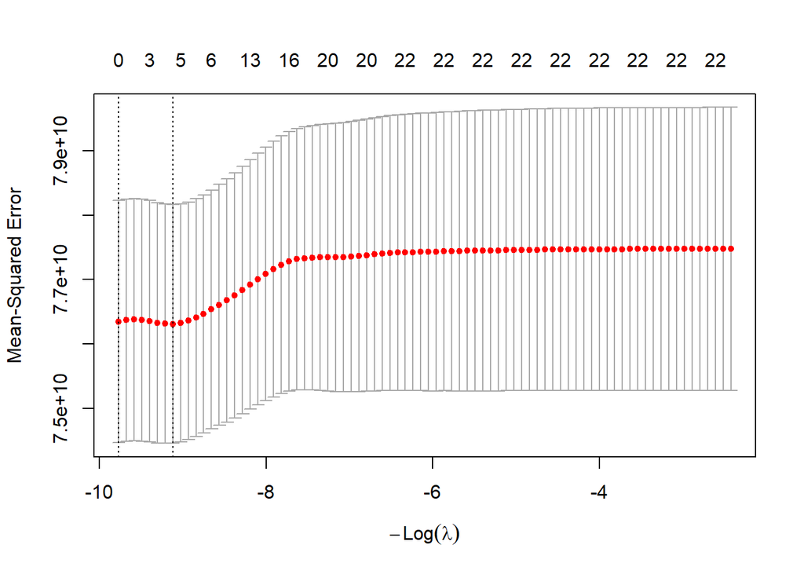

```r
set.seed(1)
lasso_cv <- cv.glmnet(
  x_train, y_train,
  alpha = 1,              # LASSO
  nfolds = 10
)

plot(lasso_cv)
```

```r
lasso_model <- glmnet(
  x_train, y_train,
  alpha = 1,
  lambda = lasso_cv$lambda.min
)

lasso_pred <- predict(lasso_model, newx = x_test)
lasso_perf <- model_performance(y_test, as.numeric(lasso_pred))
lasso_perf
```

```
##         RMSE     Rsquared          MAE
## 2.773437e+05 1.519818e-03 2.397611e+05
```

### 5.5 Ridge

Ridge regression was tuned using 10-fold cross-validation to select the optimal penalty value. The model stabilizes coefficient estimates as expected, but the test results (RMSE ~ 277K and R² ~ 0.0007) show little improvement compared with the previous linear and LASSO models, indicating that Ridge does not substantially improve predictive accuracy.

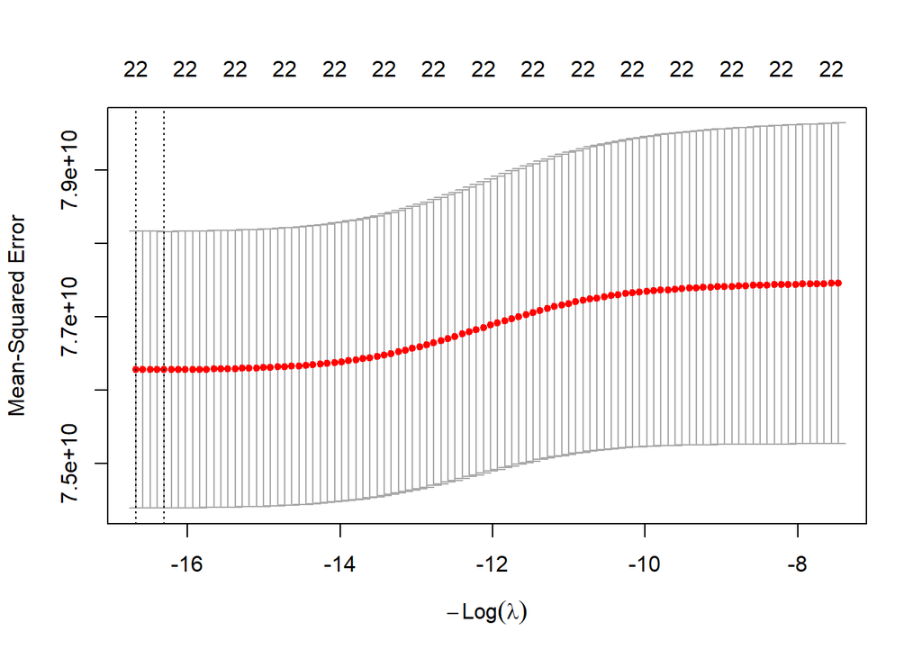

```r
set.seed(1)
ridge_cv <- cv.glmnet(
  x_train, y_train,
  alpha = 0,              # Ridge
  nfolds = 10
)

plot(ridge_cv)
```

```r
ridge_model <- glmnet(
  x_train, y_train,
  alpha = 0,
  lambda = ridge_cv$lambda.min
)

ridge_pred <- predict(ridge_model, newx = x_test)
ridge_perf <- model_performance(y_test, as.numeric(ridge_pred))
ridge_perf
```

```
##         RMSE     Rsquared          MAE
## 2.775281e+05 6.966896e-04 2.399672e+05
```

### 5.6 Elastic Net

Elastic Net, which combines both LASSO and Ridge penalties, was tuned using 10-fold cross-validation to select its optimal regularization strength. The model performs similarly to the individual LASSO and Ridge models, with test metrics (RMSE ≈ 277K and R² ≈ 0.0015) showing only minimal improvement. This indicates that blending the two regularization methods does not substantially enhance predictive accuracy.

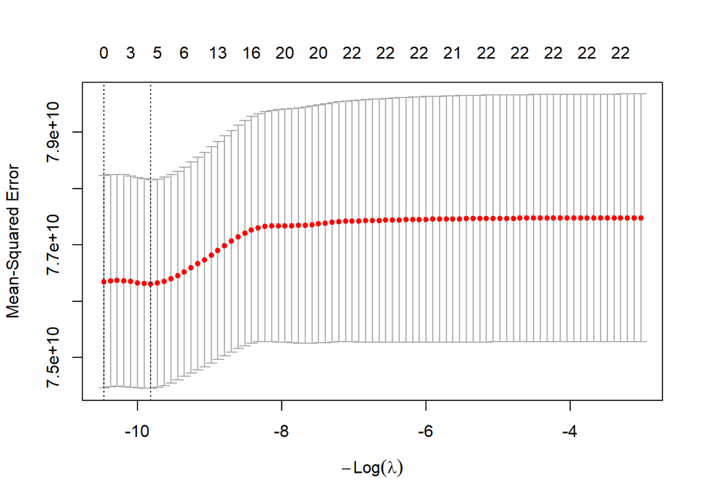

```r
set.seed(1)
elastic_cv <- cv.glmnet(
  x_train, y_train,
  alpha = 0.5,            # mix of LASSO and Ridge
  nfolds = 10
)

plot(elastic_cv)
```

```r
elastic_model <- glmnet(
  x_train, y_train,
  alpha = 0.5,
  lambda = elastic_cv$lambda.min
)

elastic_pred <- predict(elastic_model, newx = x_test)
elastic_perf <- model_performance(y_test, as.numeric(elastic_pred))
elastic_perf
```

```
##         RMSE     Rsquared          MAE
## 2.773424e+05 1.516719e-03 2.397623e+05
```

### 5.7 Random Forest

The random forest model was trained with 500 trees and a default heuristic for the number of variables considered at each split. The overall predictive performance remains weak, with a test RMSE ~ 284K and an R² ~ 0. This indicates that the random forest does not capture meaningful nonlinear relationships in the data and performs similarly to the earlier linear and regularized models.

```r
set.seed(1)
rf_model <- randomForest(
  Price ~ .,
  data = train_data,
  ntree = 500,
  mtry  = floor(sqrt(ncol(train_data) - 1)),  # simple heuristic
  importance = TRUE
)

print(rf_model)
```

```
##
## Call:
##  randomForest(formula = Price ~ ., data = train_data, ntree = 500,      mtry = floor(sqrt(ncol(train_data) - 1)), importance = TRUE)
##                Type of random forest: regression
##                      Number of trees: 500
## No. of variables tried at each split: 3
##
##           Mean of squared residuals: 79671048237
##                     % Var explained: -4.7
```

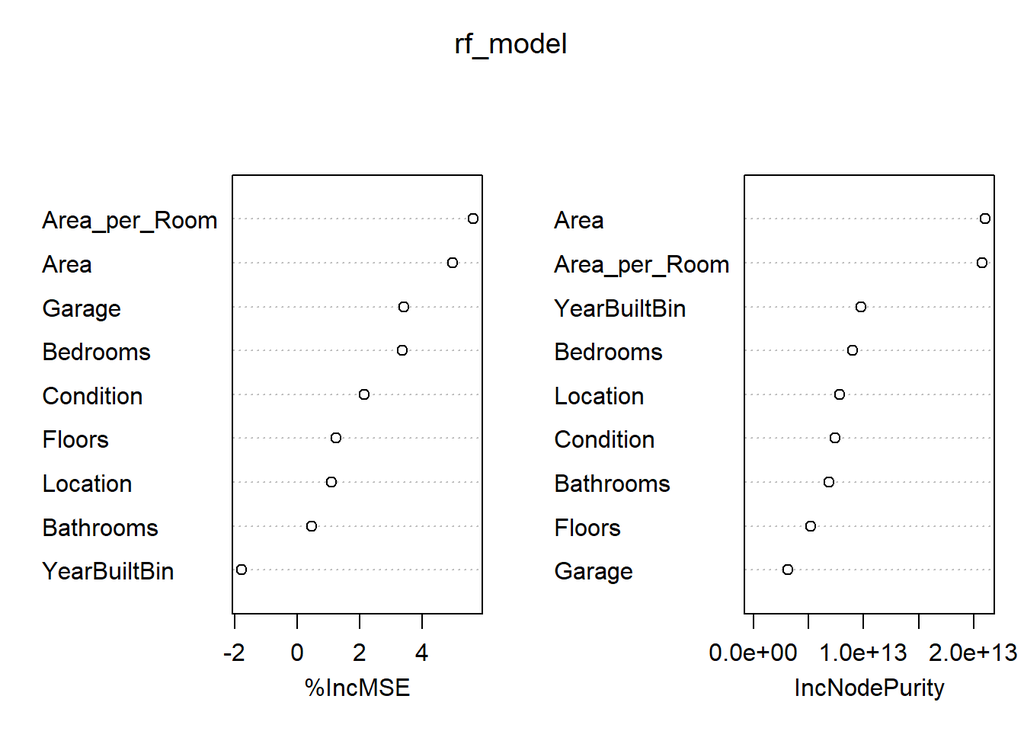

```r
varImpPlot(rf_model)
```

```r
rf_pred <- predict(rf_model, newdata = test_data)
rf_perf <- model_performance(test_data$Price, rf_pred)
rf_perf
```

```
##         RMSE     Rsquared          MAE
## 2.844661e+05 1.579524e-05 2.436575e+05
```

### 5.8 Gradient Boosting

Gradient boosting highlights `Area`, `Area_per_Room`, and `YearBuilt` as the most influential predictors. However, test performance (RMSE ≈ 277K, R² ≈ 0.002) is similar to the other models, indicating that boosting does not yield a meaningful improvement in predictive accuracy for this dataset.

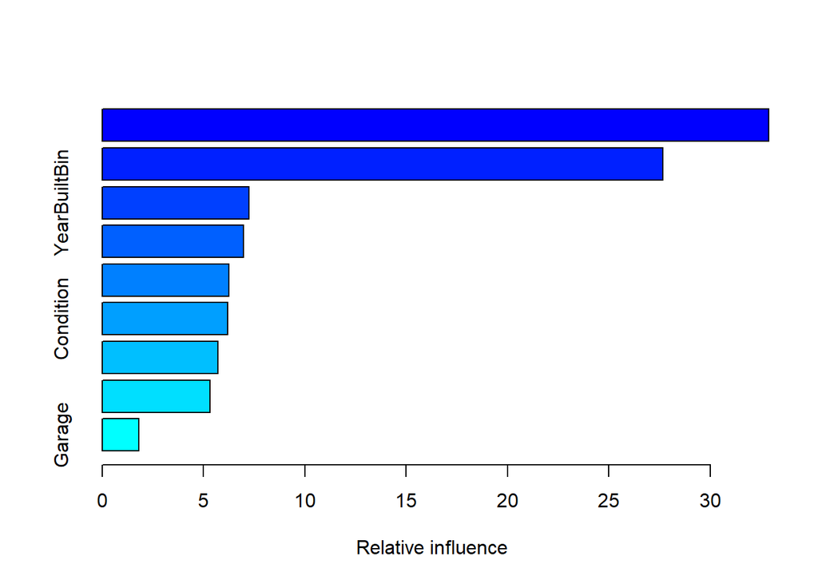

```
##                         var   rel.inf
## Area                   Area 32.883957
## Area_per_Room Area_per_Room 27.653438
## YearBuiltBin   YearBuiltBin  7.237554
## Location           Location  6.961218
## Bedrooms           Bedrooms  6.256703
## Condition         Condition  6.182769
## Bathrooms         Bathrooms  5.708768
## Floors               Floors  5.308204
## Garage               Garage  1.807388
```

```r
set.seed(1)
gbm_model <- gbm(
  formula = Price ~ .,
  data    = train_data,
  distribution = "gaussian",
  n.trees     = 2000,
  interaction.depth = 3,
  shrinkage   = 0.01,
  n.minobsinnode = 10,
  bag.fraction = 0.8,
  train.fraction = 1.0,
  verbose = FALSE
)

summary(gbm_model)
```

```r
best_iter <- gbm.perf(gbm_model, method = "OOB", plot.it = FALSE)

gbm_pred <- predict(
  gbm_model,
  newdata = test_data,
  n.trees = best_iter
)

gbm_perf <- model_performance(test_data$Price, gbm_pred)
gbm_perf
```

```
##         RMSE     Rsquared          MAE
## 2.775335e+05 2.078314e-03 2.399774e+05
```

## 6. Interpretation and Model Selection

### 6.1 Model Comparison

Error levels are very similar across models. RMSE range is between ~277K and ~295K, and MAE is around ~240K–251K.

R² is ~ 0 for all models. Even the best model explains less than 0.5% of the variance in `Price`, indicating that almost all variation in prices remains unexplained by the available predictors.

Overall, these results suggest that no model is able to actually predict the house price with the given data.

```r
model_results <- bind_rows(
  data.frame(Model = "Linear",        t(lm_perf)),
  data.frame(Model = "Log-Linear",    t(lm_log_perf)),
  data.frame(Model = "Log-Linear + Interactions", t(lm_log_int_perf)),
  data.frame(Model = "LASSO",         t(lasso_perf)),
  data.frame(Model = "Ridge",         t(ridge_perf)),
  data.frame(Model = "Elastic Net",   t(elastic_perf)),
  data.frame(Model = "Random Forest", t(rf_perf)),
  data.frame(Model = "Gradient Boosting", t(gbm_perf))
)

model_results <- model_results %>%
  arrange(RMSE)   # lower RMSE is better

model_results
```

```
##                       Model     RMSE     Rsquared      MAE
## 1               Elastic Net 277342.4 1.516719e-03 239762.3
## 2                     LASSO 277343.7 1.519818e-03 239761.1
## 3                     Ridge 277528.1 6.966896e-04 239967.2
## 4         Gradient Boosting 277533.5 2.078314e-03 239977.4
## 5                    Linear 278576.5 2.588715e-03 239451.0
## 6             Random Forest 284466.1 1.579524e-05 243657.5
## 7                Log-Linear 292810.6 5.104606e-03 249686.0
## 8 Log-Linear + Interactions 294868.4 3.926175e-03 251405.9
```

### 6.2 Selected model

Because all models performed similarly, model selection is driven more by simplicity and stability than by accuracy:

### 6.3 Limitations

The modeling results highlight several limitations of the dataset:

- The available predictors (area, number of rooms , location category, condition indicators, etc.) do not appear to capture the key factors that typically drive housing prices in the real world. Important variables such as detailed neighborhood attributes, proximity to services, and market conditions are missing.
- The weak relationships between Price and the predictors, observed both in the exploratory analysis and in the models’ low R² values, suggest that the dataset may be simulated.
- Because all models perform similarly and none achieve meaningful predictive accuracy, increasing model complexity is unlikely to provide substantial improvement without better predictors.

In summary, although Elastic Net is reported as the selected model, the broader conclusion is that this dataset is not suitable for accurate house price prediction. Practical use would require collecting more informative variables or revisiting how the data were generated to ensure that realistic price–feature relationships exist.